# Risk Factor Analysis

## Outcome Variable

**Outcome Variable:** ever_wasted

## Predictor Variables

**Intervention Variable:** predfeed6

**Adjustment Set:**

unadjusted

## Stratifying Variables

The analysis was stratified on these variable(s):

- agecat
- studyid
- country

## Data Summary

| agecat | studyid | country | predfeed6 | ever_wasted | n_cell | n |
| --- | --- | --- | --- | --- | --- | --- |
| 0-24 months (no birth wast) | EE | PAKISTAN | 1 | 0 | 21 | 48 |
| 0-24 months (no birth wast) | EE | PAKISTAN | 1 | 1 | 22 | 48 |
| 0-24 months (no birth wast) | EE | PAKISTAN | 0 | 0 | 3 | 48 |
| 0-24 months (no birth wast) | EE | PAKISTAN | 0 | 1 | 2 | 48 |
| 0-24 months (no birth wast) | GMS-Nepal | NEPAL | 1 | 0 | 176 | 560 |
| 0-24 months (no birth wast) | GMS-Nepal | NEPAL | 1 | 1 | 241 | 560 |
| 0-24 months (no birth wast) | GMS-Nepal | NEPAL | 0 | 0 | 66 | 560 |
| 0-24 months (no birth wast) | GMS-Nepal | NEPAL | 0 | 1 | 77 | 560 |
| 0-24 months (no birth wast) | LCNI-5 | MALAWI | 1 | 0 | 42 | 271 |
| 0-24 months (no birth wast) | LCNI-5 | MALAWI | 1 | 1 | 5 | 271 |
| 0-24 months (no birth wast) | LCNI-5 | MALAWI | 0 | 0 | 204 | 271 |
| 0-24 months (no birth wast) | LCNI-5 | MALAWI | 0 | 1 | 20 | 271 |
| 0-24 months (no birth wast) | MAL-ED | BANGLADESH | 1 | 0 | 62 | 233 |
| 0-24 months (no birth wast) | MAL-ED | BANGLADESH | 1 | 1 | 23 | 233 |
| 0-24 months (no birth wast) | MAL-ED | BANGLADESH | 0 | 0 | 116 | 233 |
| 0-24 months (no birth wast) | MAL-ED | BANGLADESH | 0 | 1 | 32 | 233 |
| 0-24 months (no birth wast) | MAL-ED | BRAZIL | 1 | 0 | 29 | 210 |
| 0-24 months (no birth wast) | MAL-ED | BRAZIL | 1 | 1 | 1 | 210 |
| 0-24 months (no birth wast) | MAL-ED | BRAZIL | 0 | 0 | 168 | 210 |
| 0-24 months (no birth wast) | MAL-ED | BRAZIL | 0 | 1 | 12 | 210 |
| 0-24 months (no birth wast) | MAL-ED | INDIA | 1 | 0 | 10 | 216 |
| 0-24 months (no birth wast) | MAL-ED | INDIA | 1 | 1 | 1 | 216 |
| 0-24 months (no birth wast) | MAL-ED | INDIA | 0 | 0 | 126 | 216 |
| 0-24 months (no birth wast) | MAL-ED | INDIA | 0 | 1 | 79 | 216 |
| 0-24 months (no birth wast) | MAL-ED | NEPAL | 1 | 0 | 10 | 225 |
| 0-24 months (no birth wast) | MAL-ED | NEPAL | 1 | 1 | 2 | 225 |
| 0-24 months (no birth wast) | MAL-ED | NEPAL | 0 | 0 | 169 | 225 |
| 0-24 months (no birth wast) | MAL-ED | NEPAL | 0 | 1 | 44 | 225 |
| 0-24 months (no birth wast) | MAL-ED | PERU | 1 | 0 | 87 | 271 |
| 0-24 months (no birth wast) | MAL-ED | PERU | 1 | 1 | 5 | 271 |

[output cut: 102 more lines]

The following strata were considered:

- agecat: 0-24 months (no birth wast), studyid: EE, country: PAKISTAN
- agecat: 0-24 months (no birth wast), studyid: GMS-Nepal, country: NEPAL
- agecat: 0-24 months (no birth wast), studyid: LCNI-5, country: MALAWI
- agecat: 0-24 months (no birth wast), studyid: MAL-ED, country: BANGLADESH
- agecat: 0-24 months (no birth wast), studyid: MAL-ED, country: BRAZIL
- agecat: 0-24 months (no birth wast), studyid: MAL-ED, country: INDIA
- agecat: 0-24 months (no birth wast), studyid: MAL-ED, country: NEPAL
- agecat: 0-24 months (no birth wast), studyid: MAL-ED, country: PERU
- agecat: 0-24 months (no birth wast), studyid: MAL-ED, country: SOUTH AFRICA
- agecat: 0-24 months (no birth wast), studyid: MAL-ED, country: TANZANIA, UNITED REPUBLIC OF
- agecat: 0-24 months (no birth wast), studyid: SAS-FoodSuppl, country: INDIA
- agecat: 0-6 months (no birth wast), studyid: EE, country: PAKISTAN
- agecat: 0-6 months (no birth wast), studyid: GMS-Nepal, country: NEPAL
- agecat: 0-6 months (no birth wast), studyid: LCNI-5, country: MALAWI
- agecat: 0-6 months (no birth wast), studyid: MAL-ED, country: BANGLADESH
- agecat: 0-6 months (no birth wast), studyid: MAL-ED, country: BRAZIL
- agecat: 0-6 months (no birth wast), studyid: MAL-ED, country: INDIA
- agecat: 0-6 months (no birth wast), studyid: MAL-ED, country: NEPAL
- agecat: 0-6 months (no birth wast), studyid: MAL-ED, country: PERU
- agecat: 0-6 months (no birth wast), studyid: MAL-ED, country: SOUTH AFRICA
- agecat: 0-6 months (no birth wast), studyid: MAL-ED, country: TANZANIA, UNITED REPUBLIC OF
- agecat: 0-6 months (no birth wast), studyid: SAS-FoodSuppl, country: INDIA
- agecat: 6-24 months, studyid: EE, country: PAKISTAN
- agecat: 6-24 months, studyid: GMS-Nepal, country: NEPAL
- agecat: 6-24 months, studyid: LCNI-5, country: MALAWI
- agecat: 6-24 months, studyid: MAL-ED, country: BANGLADESH
- agecat: 6-24 months, studyid: MAL-ED, country: BRAZIL
- agecat: 6-24 months, studyid: MAL-ED, country: INDIA
- agecat: 6-24 months, studyid: MAL-ED, country: NEPAL
- agecat: 6-24 months, studyid: MAL-ED, country: PERU
- agecat: 6-24 months, studyid: MAL-ED, country: SOUTH AFRICA
- agecat: 6-24 months, studyid: MAL-ED, country: TANZANIA, UNITED REPUBLIC OF
- agecat: 6-24 months, studyid: SAS-FoodSuppl, country: INDIA

### Dropped Strata

Some strata were dropped due to rare outcomes:

- agecat: 0-24 months (no birth wast), studyid: EE, country: PAKISTAN
- agecat: 0-24 months (no birth wast), studyid: MAL-ED, country: BRAZIL
- agecat: 0-24 months (no birth wast), studyid: MAL-ED, country: INDIA
- agecat: 0-24 months (no birth wast), studyid: MAL-ED, country: NEPAL
- agecat: 0-24 months (no birth wast), studyid: MAL-ED, country: SOUTH AFRICA
- agecat: 0-24 months (no birth wast), studyid: MAL-ED, country: TANZANIA, UNITED REPUBLIC OF
- agecat: 0-24 months (no birth wast), studyid: SAS-FoodSuppl, country: INDIA
- agecat: 0-6 months (no birth wast), studyid: EE, country: PAKISTAN
- agecat: 0-6 months (no birth wast), studyid: LCNI-5, country: MALAWI
- agecat: 0-6 months (no birth wast), studyid: MAL-ED, country: BRAZIL
- agecat: 0-6 months (no birth wast), studyid: MAL-ED, country: INDIA
- agecat: 0-6 months (no birth wast), studyid: MAL-ED, country: NEPAL
- agecat: 0-6 months (no birth wast), studyid: MAL-ED, country: PERU
- agecat: 0-6 months (no birth wast), studyid: MAL-ED, country: SOUTH AFRICA
- agecat: 0-6 months (no birth wast), studyid: MAL-ED, country: TANZANIA, UNITED REPUBLIC OF
- agecat: 0-6 months (no birth wast), studyid: SAS-FoodSuppl, country: INDIA
- agecat: 6-24 months, studyid: EE, country: PAKISTAN
- agecat: 6-24 months, studyid: MAL-ED, country: BRAZIL
- agecat: 6-24 months, studyid: MAL-ED, country: INDIA
- agecat: 6-24 months, studyid: MAL-ED, country: NEPAL
- agecat: 6-24 months, studyid: MAL-ED, country: PERU
- agecat: 6-24 months, studyid: MAL-ED, country: SOUTH AFRICA
- agecat: 6-24 months, studyid: MAL-ED, country: TANZANIA, UNITED REPUBLIC OF
- agecat: 6-24 months, studyid: SAS-FoodSuppl, country: INDIA

## Methods Detail

We’re interested in the causal parameters $E[Y_a]$ for all values of $a \in \mathcal{A}$. These parameters represent the mean outcome if, possibly contrary to fact, we intervened to set all units to have $A=a$. Under the randomization and positivity assumptions, these are identified by the statistical parameters $\psi_a=E_W[E_{Y|A,W}(Y|A=a,W)]$. In addition, we’re interested in the mean of $Y$, $E[Y]$ under no intervention (the observed mean). We will estimate these parameters by using SuperLearner to fit the relevant likelihood factors – $E_{Y|A,W}(Y|A=a,W)$ and $p(A=a|W)$, and then updating our likelihood fit using a joint TMLE.

For unadjusted analyses ($W=\{\}$), initial likelihoods were estimated using Lrnr_glm to estimate the simple $E(Y|A)$ and Lrnr_mean to estimate $p(A)$. For adjusted analyses, a small library containing Lrnr_glmnet, Lrnr_xgboost, and Lrnr_mean was used.

Having estimated these parameters, we will then use the delta method to estimate relative risks and attributable risks relative to a prespecified baseline level of $A$.

# Results Detail

## Results Plots

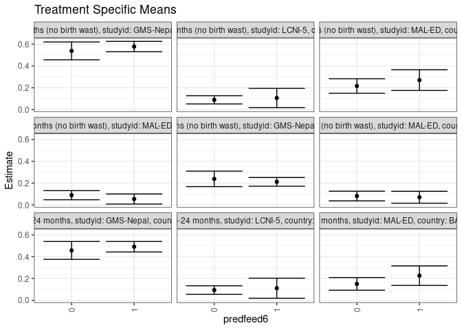

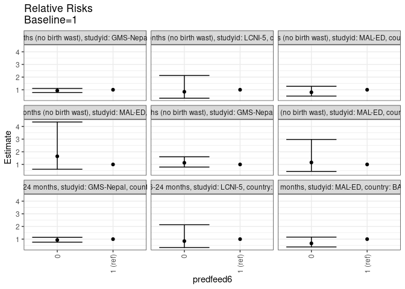

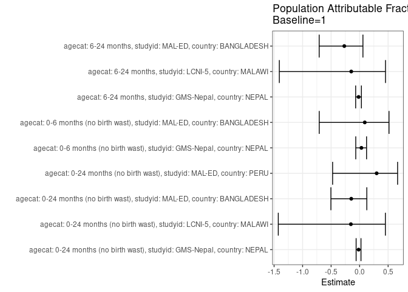

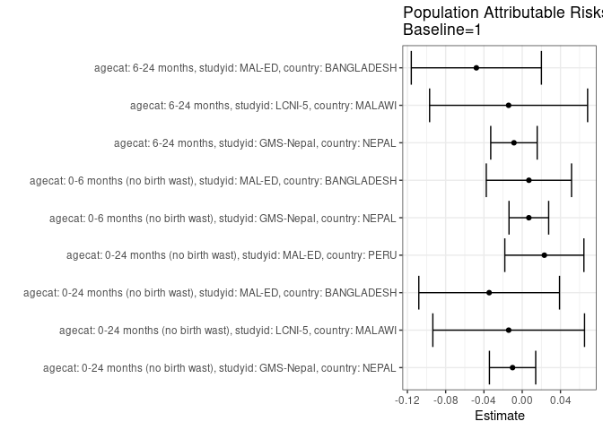

## Results Table

### Parameter: TSM

| agecat | studyid | country | intervention_level | baseline_level | estimate | ci_lower | ci_upper |
| --- | --- | --- | --- | --- | --- | --- | --- |
| 0-24 months (no birth wast) | GMS-Nepal | NEPAL | 1 | NA | 0.5779376 | 0.5304919 | 0.6253834 |
| 0-24 months (no birth wast) | GMS-Nepal | NEPAL | 0 | NA | 0.5384615 | 0.4566811 | 0.6202420 |
| 0-24 months (no birth wast) | LCNI-5 | MALAWI | 1 | NA | 0.1063830 | 0.0180722 | 0.1946938 |
| 0-24 months (no birth wast) | LCNI-5 | MALAWI | 0 | NA | 0.0892857 | 0.0518739 | 0.1266975 |
| 0-24 months (no birth wast) | MAL-ED | BANGLADESH | 1 | NA | 0.2705882 | 0.1759398 | 0.3652367 |
| 0-24 months (no birth wast) | MAL-ED | BANGLADESH | 0 | NA | 0.2162162 | 0.1497511 | 0.2826813 |
| 0-24 months (no birth wast) | MAL-ED | PERU | 1 | NA | 0.0543478 | 0.0079376 | 0.1007581 |
| 0-24 months (no birth wast) | MAL-ED | PERU | 0 | NA | 0.0893855 | 0.0475133 | 0.1312576 |
| 0-6 months (no birth wast) | GMS-Nepal | NEPAL | 1 | NA | 0.2118227 | 0.1720410 | 0.2516043 |
| 0-6 months (no birth wast) | GMS-Nepal | NEPAL | 0 | NA | 0.2391304 | 0.1678975 | 0.3103633 |
| 0-6 months (no birth wast) | MAL-ED | BANGLADESH | 1 | NA | 0.0705882 | 0.0160191 | 0.1251573 |
| 0-6 months (no birth wast) | MAL-ED | BANGLADESH | 0 | NA | 0.0816327 | 0.0372751 | 0.1259902 |
| 6-24 months | GMS-Nepal | NEPAL | 1 | NA | 0.4915663 | 0.4434245 | 0.5397081 |
| 6-24 months | GMS-Nepal | NEPAL | 0 | NA | 0.4577465 | 0.3757287 | 0.5397642 |
| 6-24 months | LCNI-5 | MALAWI | 1 | NA | 0.1111111 | 0.0191112 | 0.2031111 |
| 6-24 months | LCNI-5 | MALAWI | 0 | NA | 0.0938967 | 0.0546489 | 0.1331445 |
| 6-24 months | MAL-ED | BANGLADESH | 1 | NA | 0.2261905 | 0.1365284 | 0.3158526 |
| 6-24 months | MAL-ED | BANGLADESH | 0 | NA | 0.1506849 | 0.0925299 | 0.2088399 |

### Parameter: E(Y)

| agecat | studyid | country | intervention_level | baseline_level | estimate | ci_lower | ci_upper |
| --- | --- | --- | --- | --- | --- | --- | --- |
| 0-24 months (no birth wast) | GMS-Nepal | NEPAL | NA | NA | 0.5678571 | 0.5267918 | 0.6089225 |
| 0-24 months (no birth wast) | LCNI-5 | MALAWI | NA | NA | 0.0922509 | 0.0577338 | 0.1267680 |
| 0-24 months (no birth wast) | MAL-ED | BANGLADESH | NA | NA | 0.2360515 | 0.1814079 | 0.2906951 |
| 0-24 months (no birth wast) | MAL-ED | PERU | NA | NA | 0.0774908 | 0.0455992 | 0.1093824 |
| 0-6 months (no birth wast) | GMS-Nepal | NEPAL | NA | NA | 0.2187500 | 0.1839790 | 0.2535210 |
| 0-6 months (no birth wast) | MAL-ED | BANGLADESH | NA | NA | 0.0775862 | 0.0430879 | 0.1120845 |
| 6-24 months | GMS-Nepal | NEPAL | NA | NA | 0.4829443 | 0.4414080 | 0.5244807 |
| 6-24 months | LCNI-5 | MALAWI | NA | NA | 0.0968992 | 0.0607324 | 0.1330660 |
| 6-24 months | MAL-ED | BANGLADESH | NA | NA | 0.1782609 | 0.1286901 | 0.2278316 |

### Parameter: RR

| agecat | studyid | country | intervention_level | baseline_level | estimate | ci_lower | ci_upper |
| --- | --- | --- | --- | --- | --- | --- | --- |
| 0-24 months (no birth wast) | GMS-Nepal | NEPAL | 1 | 1 | 1.0000000 | 1.0000000 | 1.000000 |
| 0-24 months (no birth wast) | GMS-Nepal | NEPAL | 0 | 1 | 0.9316949 | 0.7839614 | 1.107268 |
| 0-24 months (no birth wast) | LCNI-5 | MALAWI | 1 | 1 | 1.0000000 | 1.0000000 | 1.000000 |
| 0-24 months (no birth wast) | LCNI-5 | MALAWI | 0 | 1 | 0.8392857 | 0.3311837 | 2.126918 |
| 0-24 months (no birth wast) | MAL-ED | BANGLADESH | 1 | 1 | 1.0000000 | 1.0000000 | 1.000000 |
| 0-24 months (no birth wast) | MAL-ED | BANGLADESH | 0 | 1 | 0.7990599 | 0.5015824 | 1.272965 |
| 0-24 months (no birth wast) | MAL-ED | PERU | 1 | 1 | 1.0000000 | 1.0000000 | 1.000000 |
| 0-24 months (no birth wast) | MAL-ED | PERU | 0 | 1 | 1.6446927 | 0.6209888 | 4.355979 |
| 0-6 months (no birth wast) | GMS-Nepal | NEPAL | 1 | 1 | 1.0000000 | 1.0000000 | 1.000000 |
| 0-6 months (no birth wast) | GMS-Nepal | NEPAL | 0 | 1 | 1.1289181 | 0.7938312 | 1.605450 |
| 0-6 months (no birth wast) | MAL-ED | BANGLADESH | 1 | 1 | 1.0000000 | 1.0000000 | 1.000000 |
| 0-6 months (no birth wast) | MAL-ED | BANGLADESH | 0 | 1 | 1.1564626 | 0.4495261 | 2.975146 |
| 6-24 months | GMS-Nepal | NEPAL | 1 | 1 | 1.0000000 | 1.0000000 | 1.000000 |
| 6-24 months | GMS-Nepal | NEPAL | 0 | 1 | 0.9311999 | 0.7592100 | 1.142152 |
| 6-24 months | LCNI-5 | MALAWI | 1 | 1 | 1.0000000 | 1.0000000 | 1.000000 |
| 6-24 months | LCNI-5 | MALAWI | 0 | 1 | 0.8450704 | 0.3342527 | 2.136539 |
| 6-24 months | MAL-ED | BANGLADESH | 1 | 1 | 1.0000000 | 1.0000000 | 1.000000 |
| 6-24 months | MAL-ED | BANGLADESH | 0 | 1 | 0.6661860 | 0.3831101 | 1.158424 |

### Parameter: PAR

| agecat | studyid | country | intervention_level | baseline_level | estimate | ci_lower | ci_upper |
| --- | --- | --- | --- | --- | --- | --- | --- |
| 0-24 months (no birth wast) | GMS-Nepal | NEPAL | 1 | NA | -0.0100805 | -0.0342659 | 0.0141049 |
| 0-24 months (no birth wast) | LCNI-5 | MALAWI | 1 | NA | -0.0141321 | -0.0934107 | 0.0651466 |
| 0-24 months (no birth wast) | MAL-ED | BANGLADESH | 1 | NA | -0.0345367 | -0.1080768 | 0.0390033 |
| 0-24 months (no birth wast) | MAL-ED | PERU | 1 | NA | 0.0231429 | -0.0181917 | 0.0644776 |
| 0-6 months (no birth wast) | GMS-Nepal | NEPAL | 1 | NA | 0.0069273 | -0.0137939 | 0.0276486 |
| 0-6 months (no birth wast) | MAL-ED | BANGLADESH | 1 | NA | 0.0069980 | -0.0375657 | 0.0515616 |
| 6-24 months | GMS-Nepal | NEPAL | 1 | NA | -0.0086219 | -0.0328981 | 0.0156543 |
| 6-24 months | LCNI-5 | MALAWI | 1 | NA | -0.0142119 | -0.0967920 | 0.0683682 |
| 6-24 months | MAL-ED | BANGLADESH | 1 | NA | -0.0479296 | -0.1159323 | 0.0200731 |

### Parameter: PAF

| agecat | studyid | country | intervention_level | baseline_level | estimate | ci_lower | ci_upper |
| --- | --- | --- | --- | --- | --- | --- | --- |
| 0-24 months (no birth wast) | GMS-Nepal | NEPAL | 1 | NA | -0.0177518 | -0.0612800 | 0.0239910 |
| 0-24 months (no birth wast) | LCNI-5 | MALAWI | 1 | NA | -0.1531915 | -1.4265796 | 0.4519650 |
| 0-24 months (no birth wast) | MAL-ED | BANGLADESH | 1 | NA | -0.1463102 | -0.5035934 | 0.1260756 |
| 0-24 months (no birth wast) | MAL-ED | PERU | 1 | NA | 0.2986542 | -0.4737013 | 0.6662242 |
| 0-6 months (no birth wast) | GMS-Nepal | NEPAL | 1 | NA | 0.0316678 | -0.0677783 | 0.1218522 |
| 0-6 months (no birth wast) | MAL-ED | BANGLADESH | 1 | NA | 0.0901961 | -0.7082806 | 0.5154524 |
| 6-24 months | GMS-Nepal | NEPAL | 1 | NA | -0.0178528 | -0.0694040 | 0.0312133 |
| 6-24 months | LCNI-5 | MALAWI | 1 | NA | -0.1466667 | -1.4083049 | 0.4540374 |
| 6-24 months | MAL-ED | BANGLADESH | 1 | NA | -0.2688734 | -0.7094406 | 0.0581482 |